# 5c: ARIMA Model

[Nao Mimoto](https://nmimoto.github.io/) - [Dept. of Statistics](http://www.uakron.edu/stat/) : [The University of Akron](http://www.uakron.edu)

[Class Web Page](https://nmimoto.github.io/477/)

## 1. Types of Trends

Now we can handle following possibilities:

- Linear Trend with ARMA noise
- Quadratic Trend with ARMA noise
- RW without drift only
- RW with drift only
- RW without drift + ARMA noise
- RW with drift + ARMA noise

## 2. ARIMA fitting

### ARIMA(p,d,q) model

Your observation $Y_t$ is modeled as ARIMA(p,d,q) if:

Take difference $d$ times. Call it $X_t$.
$$\bigtriangledown^d Y_t \hspace{3mm} = \hspace{3mm} X_t$$

Then model $X_t$ with ARMA(p,q) model:
$$\Phi(B) \, X_t \hspace{3mm} = \hspace{3mm} \Theta(B) \, \epsilon_t$$
where $\epsilon_t\sim WN(0,\sigma^2)$.

**ARIMA(p,d,q) model means you difference the data $d$ times, then you get ARMA($p,q$).**

## 3. ARIMA(p,d,q) Modeling Workflow

Let $Y$ be the original time series.

Hyndman-Khandakar algorithm for automatic ARIMA modelling in The number of differences $d$ is determined using repeated KPSS tests.

For value of $d$ selected by **auto.arima()**, take the difference by hand, and use **Stationarity.tests()** to see what other tests say.

### Preliminary Analysis

Is $Y$ stationary? Use **Stationarity.tests()**. If all three points to stationarity, then set $d=0$ and perform ARMA(p,q) analysis.

If **Stationarity.tests(Y)** indicates non-stationarity, but **Stationarity.tests( diff(Y) )** indicates to stationarity, then it is a clear $d=1$ case.

If test results are mixed, then use all values of $d$ that is plausible. For example, if **Stationarity.tests( Y )** has mixed answer, and **Stationarity.tests( diff(Y) )** indicates stationarity, then perform both $d=0$ analysis and $d=1$ analysis.

You can take difference again by **diff(diff(Y))**.

### (1) d=0 Direct ARMA(p,q)

Take no difference. Directly fit ARMA(p,q) with d=0. This is same as ARMA analysis.

This model is assuming that $Y$ is stationary.

### (2) d=1 ARIMA with random trend

Take difference once then fit ARMA(p,q). Use

```r
  auto.arima(Y, d=1, stepwise=FALSE, approximation=FALSE)
```

This model assumes $Y$ is not stationary, and either have random trend without drift, random trend with drift, or linear trend.

If no drift term is suggested **auto.arima()**, include it using Arima(), and check for significance.

```r
  Arima(Y, order=c(p,1,q), include.drift=TRUE)
```

### (3) d=0 Linear Trend + ARMA(p,q)

This model is assuming that $Y$ is not stationary, with linear deterministic trend.

Do this if $Y$ appear to have a linear trend.

For thie model to be valid, (2) must have significant drift term

If this model is true, then residuals after regression must return stationary series.

```r
  Reg1 = lm(Y ~ time(Y))               # fit a line to Y
  Stationarity.tests(Reg1$residuals)   # test stationarity of regression residuals

  # fit ARMA to the regression residuals
  Fit_Reg1 = auto.arima(Reg1$residuals, d=0, stepwise=FALSE, approximation=FALSE)
  Fit_Reg2 = Arima(Reg1$residuals, order=c(p,0,q))

  # Fit a line to Y, then fit ARMA to the regression residuals at once.
  Fit1 = auto.arima(Y, d=0, xreg=time(Y), stepwise=FALSE, approximation=FALSE)
  Fit2 = Arima(Y, order=c(p,0,q), xreg=time(Y))
  Randomness.tests(Fit1$residuals)
```

## 4. Signs of over- and under-differencing

You CAN’T use AICc to compare between models with different $d$.

### Underdifferencing ($d$ is too small)

Force to fit AR(1) to your series, and see if $\phi_1$ is significantly different from 1.

If it is close to 1, it indicates that the series is underdifferenced. (current series is non-stationary.)

$\phi_1=1$ means that we have unit-root AR.

### Overdifferencing ($d$ is too large)

Force to fit MA(1) to your sereis, and see if $\theta_1$ is significantly different from -1.

Suppose $\delta X_t = Y_t$
$$Y_t \hspace{3mm} = \hspace{3mm} \epsilon_t$$

Each step has now little more change of being positive than negative.
$$P(\epsilon_t >0) = .54 \hspace{10mm} P(\epsilon_t \leq 0) = .46.$$

Take $\bigtriangledown$ again, then you get
$$\bigtriangledown Y_t = \epsilon_t - \epsilon_{t-1}$$
Now we got MA(1) with $\theta_1 = 1$. That’s not invertible.

Suppose
$$\bigtriangledown X_t \hspace{3mm} = \hspace{3mm} Y_t\\ \\
Y_t \hspace{3mm} = \hspace{3mm} \epsilon_t - \theta_1 \epsilon_{t-1}$$
If you take $\bigtriangledown$ again,
$$\bigtriangledown Y_t \hspace{3mm} = \hspace{3mm} (\epsilon_t -
\theta_1 \epsilon_{t-1}) - (\epsilon_{t-1} - \theta_1 \epsilon_{t-2}) \\
\\
\hspace{3mm} = \hspace{3mm} (\epsilon_t -
(1+\theta_1) \epsilon_{t-1} + \theta_1 \epsilon_{t-2}) .$$

So $\bigtriangledown Y_t$ is MA(2) with
$$\Theta(z) \hspace{3mm} = \hspace{3mm} 1 - (1+\theta_1) z + \theta_1
z^2$$
Root is

$$\begin{align}
\frac{-b \pm \sqrt{b^2\pm 4ac}}{2a}
&= \hspace{3mm} \frac{(1+\theta_1) \pm
\sqrt{(1+\theta_1)^2-4\theta_1}}{ 2\theta_1} \\ \\
&= \hspace{3mm} \frac{(1+\theta_1) \pm \sqrt{1- 2 \theta_1 +
\theta_1^2}}{ 2 \theta_1} \\ \\
&= \hspace{3mm} \frac{(1+\theta_1) \pm \sqrt{(1- \theta_1)^2}}{
2 \theta_1} \\ \\
&= \hspace{3mm} \frac{2}{2 \theta_1} \hspace{3mm} \mbox{or}
\hspace{3mm}
\frac{2\theta_1}{2 \theta_1}
\end{align}$$
That’s a unit root!

Testing Unit-Root in MA(q) polynomials $\to$ not fully resolved.

Test Unit-Root in MA(1) $\to$ see if $\hat\theta_1$ is significantly different from -1.

### ARMA with same polynomials

Suppose you have ARMA(1,1) with
$$Y_t - .5 Y_{t-1} = \epsilon_t - .5 \epsilon_{t-1}$$
Then this is

$$\begin{align}
(1-.5 B) Y_t
&= \hspace{3mm} (1-.5 B) \epsilon_t \\\\
&= \hspace{3mm} \epsilon_t
\end{align}$$

So $Y_t$ is just a white noise.

larain in package TSA is good example for this.

### Ex: LArain data

Check for same characteristic polynomials.

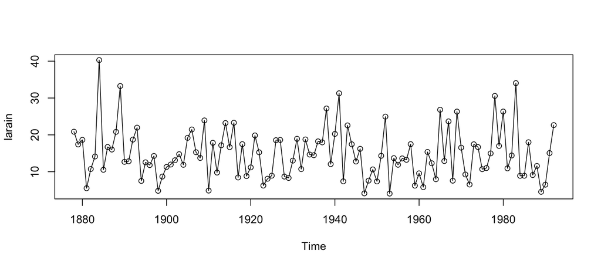

```r
  library(forecast)
  source('https://nmimoto.github.io/R/TS-00.txt')

  acf.orig = acf;  library(TSA);  acf = acf.orig

  data(larain)

  plot(larain, type="o")
```

```r
  Arima(larain, order=c(1,0,1))
```

```
## Series: larain
## ARIMA(1,0,1) with non-zero mean
##
## Coefficients:
##           ar1     ma1     mean
##       -0.3402  0.3006  14.8848
## s.e.   0.9121  0.9185   0.6196
##
## sigma^2 = 48.1:  log likelihood = -384.38
## AIC=776.76   AICc=777.12   BIC=787.74
```

When orders of AR and MA mathces, watch out for equal value of parameters. It may indicate WN.

If MA(1) gives you $-1$, it indicates the over-differencing.